# Time Series Lab 3: Model Fitting

1. Fitting the AR model

I will be using the lynx dataset

```r
head(lynx) #look at the first results of lynx
```

```
[1]  269  321  585  871 1475 2821
```

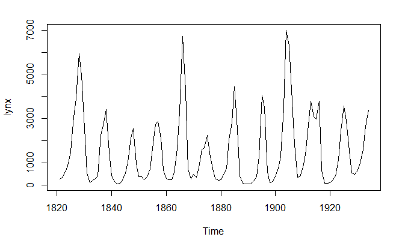

```r
ts.plot(lynx) #plot as a time series
```

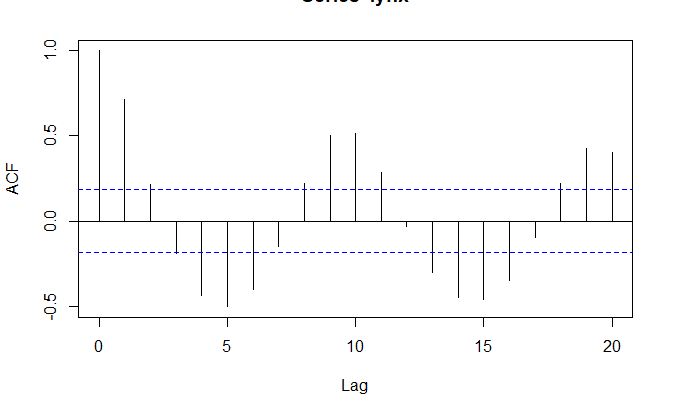

```r
acf(lynx) #plot autocorellation function
```

There is evidently a 10-year sinusoidal seasonality effect, meaning the series is not stationary - the average changes over time.

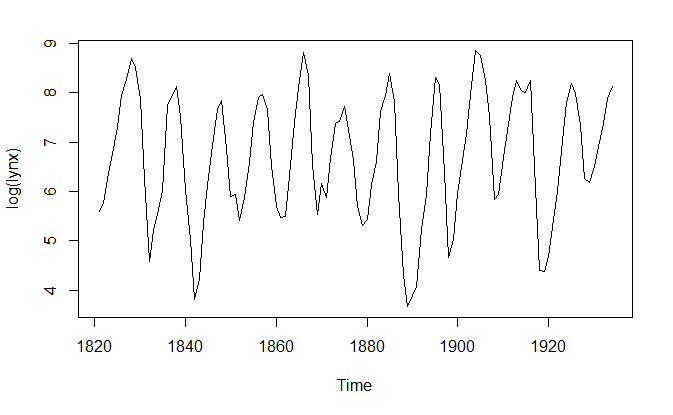

```r
ts.plot(log(lynx)) #time-plot the logarithm of the lynx dataset
```

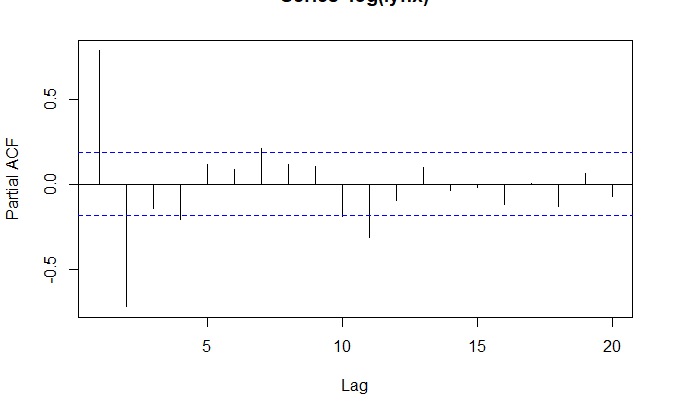

```r
acf(log(lynx), type="partial") #partial-acf plot for log-lynx
```

```r
llynx.ar <- ar.yw(log(lynx)) #fit the AR model to log-lynx
llynx.ar$order.max #request highest value of order to fit model to
```

```
[1] 20
```

```r
llynx.ar$aic #request information criterion for order-values
```

```
          0           1           2           3           4           5
203.6857209  96.4501839  15.1465358  14.7887795  11.8370889  12.3136364
          6           7           8           9          10          11
 13.4955841  10.4663974  10.8577774  11.6462100   9.5932581   0.0000000
         12          13          14          15          16          17
  0.9553046   1.8797869   3.7330981   5.6780223   6.0010835   7.9974194
         18          19          20
  7.9677046   9.5235726  10.8983482
```

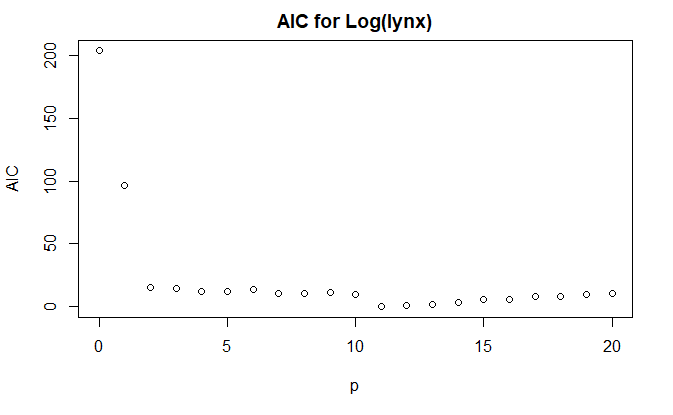

```r
plot(0:llynx.ar$order.max,llynx.ar$aic,main="AIC for Log(lynx)",xlab="p",ylab="AIC") #plot AIC
```

I can see that the AIC is lowest at p=11. I now need to obtain the parameters for my model from the llynx object, namely coefficients of Xt and the mean estimate.

```r
llynx.ar$ar #find coefficients up to order p=11
```

```
 [1]  1.13870861 -0.50803338  0.21265078 -0.27017697  0.11269003 -0.12398034
 [7]  0.06772419 -0.04004242  0.13370007  0.18527305 -0.31095853
```

```r
llynx.ar$x.mean #find mean estimate
```

```
[1] 6.685933
```

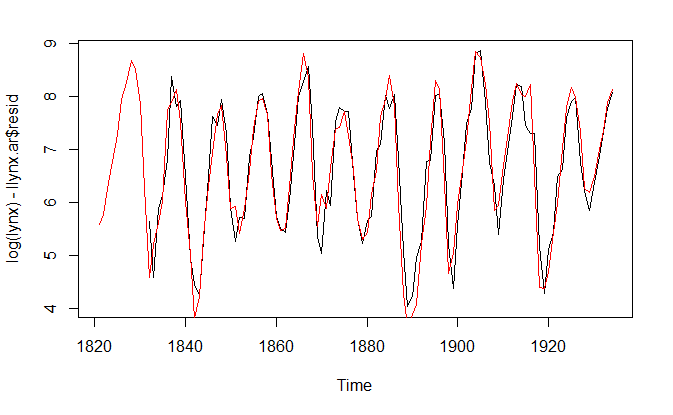

```r
ts.plot(log(lynx)-llynx.ar$resid) #time series plot the fit of the model
lines(log(lynx),col=2) #overlay a red line of the original series
```

Observing the graph, it seems I have found a suitable model for the series.

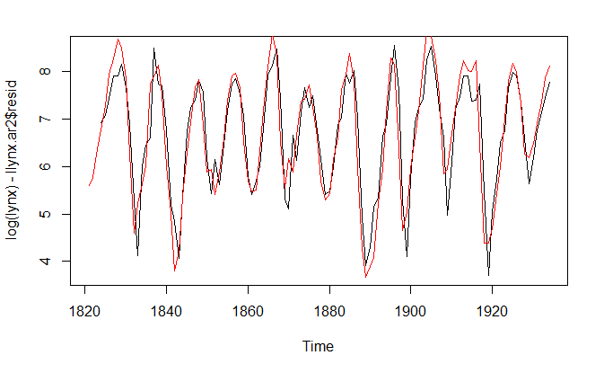

```r
llynx.ar2 <- ar.yw(log(lynx), order.max = 3) #fit a new model of order 3
ts.plot(log(lynx)-llynx.ar2$resid) #time series plot the fit of the model
lines(log(lynx),col=2) #overlay a red line of the original series
```

This seems to also be an adequate model for the series, though seems to underestimate the peaks of the series.

////////////////////////////////////////////////////////////////////////////////////

2. Fitting the ARIMA model

I’ll be using the dataset wool.

“The wool data set contains prices monitored by the Australian Wool Corporation from June 1976 to June 1984. The prices are monitored weekly with some breaks for public holidays, for example over the Christmas period there is a break of several weeks. Before the start of each week the Corporation sets a floor price for the week. The Corporation guarantees that it will pay this price for the wool during the week. The actual price of the wool is an average taken over the following week and is never less than the floor price (otherwise they could have sold it to the Corporation and made more money)”

I can look at the ratio of actual to floor price as this will compensate for trends such as those caused by currency fluctuations and inflation. Price movements are often multiplicative in nature (so price increases/decreases tend to be discussed in percentage terms rather than absolute terms), giving reason to use the logarithm of the ratio.

```r
load(url("https://people.maths.bris.ac.uk/???magpn/TSA/TSA.RData")) #load data
```

[output not shown]

I will fit the ARIMA model to the series {Lt}, ignoring missing days. I first need to establish stationarity.

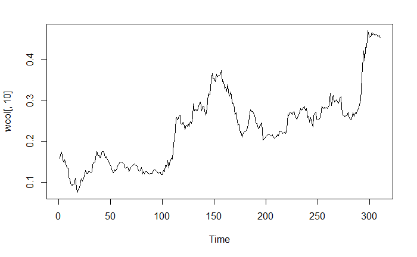

This is clearly not stationary, so I take the difference.

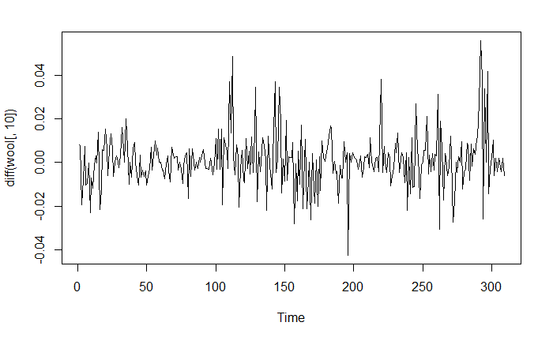

By observation, the variance seems to change after t=100. I wish to forecast future results, so I discard the first 100 and consider the later results.

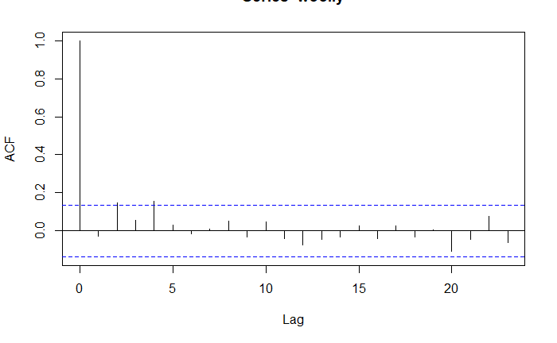

```r
tmp <- diff(wool[,10]) #create vector of differenced Lt
woolly <- tmp[101:309] #select last 209 observations
acf(woolly) #plot autocorrelation function
```

From the acf, I have evidence that my observations may come from the white noise model. I could consider the second and fourth autocorrelations in my model, though parsimony dictates that I should make do with the least information possible for a sufficient model. No other pattern is visible in the acf, such as trend or seasonality.

I use the first model

Lt - Lt-1 = mu + Zt

I’ll test the hypothesis Ho: mu=0 against H1: mu =/= 0

```r
var(woolly) #find sample variance
```

```
[1] 0.0001900347
```

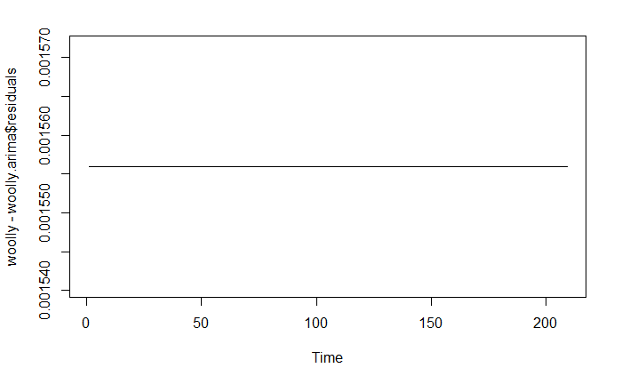